# Installing RStudio

### **1. Install R:**

Before installing RStudio, you need to have R installed on your system.

#### **For Ubuntu:**

1. Open the terminal.
2. Update your package list:

   ```bash
   sudo apt update
   ```

3. Install R:

   ```bash
   sudo apt install r-base
   ```

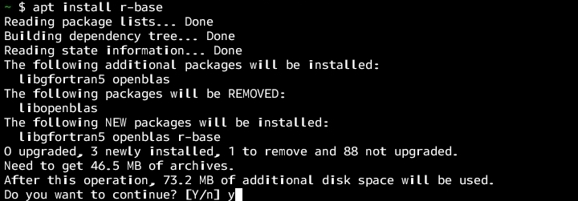

   installing r-base

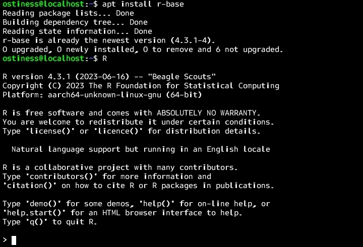

4. installing r-base

#### **For Windows:**

1. Download the R installer from the [CRAN R Project website](https://cran.r-project.org/).
2. Run the installer and follow the on-screen instructions.

#### **For macOS:**

1. Download the R installer for macOS from the [CRAN R Project website](https://cran.r-project.org/).
2. Run the installer and follow the on-screen instructions.

### **2. Install RStudio:**

Once R is installed, you can install RStudio.

#### **For Ubuntu:**

1. Go to the [RStudio download page](https://rstudio.com/products/rstudio/download/#download).
2. Download the `.deb` package suitable for your Ubuntu version.

[figure not shown]

   download rstudio

3. Install the downloaded package using:

   ```bash
   sudo dpkg -i rstudio-x.yy.zz-amd64.deb
   ```

4. If you encounter dependency issues, run:

   ```bash
   sudo apt --fix-broken install
   ```

5. If your machine is not amd64 or x86_64 I.e it’s maybe arm64, you’ll need to download rstudio from a build site

[figure not shown]

   downloading for arm64

6. Install the downloaded package using:

   ```bash
   sudo dpkg -i rstudio-x.yy.zz-arm64.deb
   ```

#### **For Windows:**

1. Download the RStudio installer from the [RStudio download page](https://rstudio.com/products/rstudio/download/#download).
2. Run the installer and follow the on-screen instructions.

#### **For macOS:**

1. Download the RStudio installer from the [RStudio download page](https://rstudio.com/products/rstudio/download/#download).
2. Open the downloaded `.dmg` file and drag the RStudio icon into your Applications folder.

### **3. Launch RStudio:**

After installation, you can launch RStudio from your applications menu (on Ubuntu and macOS) or from the Start menu (on Windows).

[figure not shown]

[figure not shown]

[figure not shown]

[figure not shown]

editor

[figure not shown]

files

## Installing Packages

installing required packages for data mining

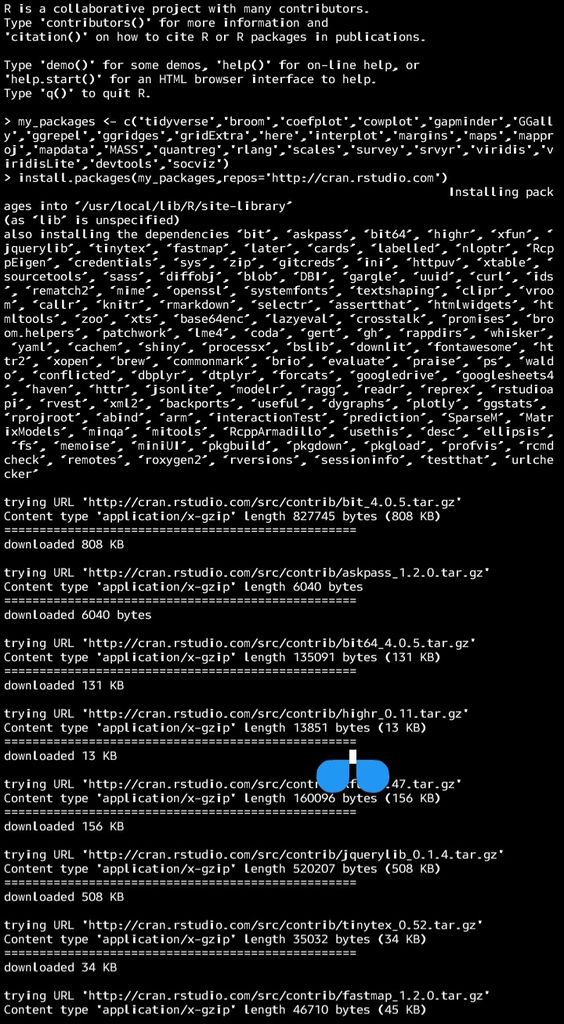

installing packages

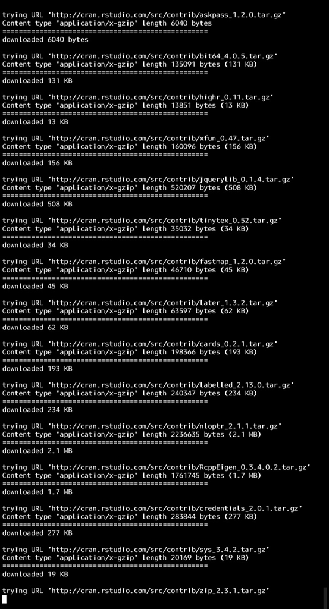

installing packages